# Введение в МО: каким оно бывает и каковы основные компоненты

**Машинное обучение (Machine learning)** — комплекс методов и инструментов, позволяющий компьютеру строить модели с сильной экспертизой на основе входящих из реального мира данных и накопленных человеком знаний и опыта.

Два основных блока, рассматриваемых в машинном обучении — **классическое машинное обучение и глубокое обучение (Deep learning)**.

**Датасет (Dataset)** — структурированный набор данных, как правило, представленный в виде одной или нескольких таблиц, где строкам соответствуют некие `объекты` (objects), а столбцам - их `признаки` (features).

**Признаки или фичи** (Features) — некоторые характеристики, на основе которых проводится обучение модели.

**Алгоритм (Algorithm)** — набор однозначных пошаговых инструкций, которые компьютер может выполнять для достижения определенной цели.

**Модель (Model)** — некая абстракция, с помощью данных обученная распознавать определенные типы закономерностей.

**Ответ или целевая переменная (Target)** — признак датасета, который предстоит предсказывать модели машинного обучения.

**Множество** — совокупность объектов (элементов множества).

Запись вида $U={q,w,r,t}$ означает, что множество U состоит из четырех элементов — $q,w,r,t.$

`R` — множество действительных чисел, числа, которые можно записать в виде конечной или бесконечной, периодической или непериодической десятичной дроби $(R=1;−1;\frac{1}{2} ;0,12;π;\sqrt{2};...)$

`Z` — множество целых чисел $(Z = {...-3, -2, -1, 0, 1, 2, 3, ...})$.

`⊂` — знак включения элемента как подмножества множества $(Z ⊂ R)$.

`∈` — знак принадлежности отдельного элемента к множеству $(a ∈ Z)$.

Подробней о множествах и их условных обозначениях тут:

http://mathprofi.ru/mnozhestva.html

## Задачи машинного обучения

**Примеры задач, решаемых с помощью машинного обучения:**

- Максимизация прибыли от инвестиций за счет прогноза стоимости акций
- Принятие стратегических управленческих решений на основе данных
- Определение кредитоспособности (скоринг) банковских клиентов
- Поиск аномалий в процессах (например, на опасном производстве)
- Минимизация расходов на рекламу за счет оптимизации рекламной кампании
- Ответы на другие сложные вопросы

**Главные преимущества моделей машинного обучения по сравнению с человеческой экспертизой:**

- Высокая скорость ответа
- Масштабируемость и доступность
- Решение сложных задач
- Работа с большим объемом данных

## Основные типы задач машинного обучения

### Обучение с учителем (Supervised Learning)

**Построение моделей, основанных на прецедентах** (когда есть примеры правильных ответов, на которых обучается модель).

- `Регрессия` — предсказание некого числового значения (например, цена квартиры по ее площади и расположению или капитализация компании по ее характеристикам). Число это не ограничено.
- `Классификация (бинарная/многоклассовая)` — определение объекта в ту или иную заранее определенную группу, т.е. множество ответов ограничено и известно.

### Обучение без учителя (Unsupervised Learning)

- `Кластеризация` — объединение объектов в группы, сходных по неким признакам (сегментация пользователей, группы генов с похожей экспрессией). При этом заренее не известно, какие это будут группы.
- `Рекомендательные системы` — подбор контента на основе предыдущего поведения пользователя (например подбор фильма на основе предыдущих оценок).
- `Поиск аномалий` — поиск объекта, сильно отличающегося от других.

### Обучение с подкреплением (Reinforcement Learning)

Ответ заранее неизвестен. Cистема обучается самостоятельно, взаимодействуя с некоторой средой, получая от нее негативные и позитивные сигналы, тем самым как бы сама выступая в роли учителя.

Статьи:

https://vas3k.ru/blog/machine_learning/

https://vas3k.ru/blog/machine_learning/

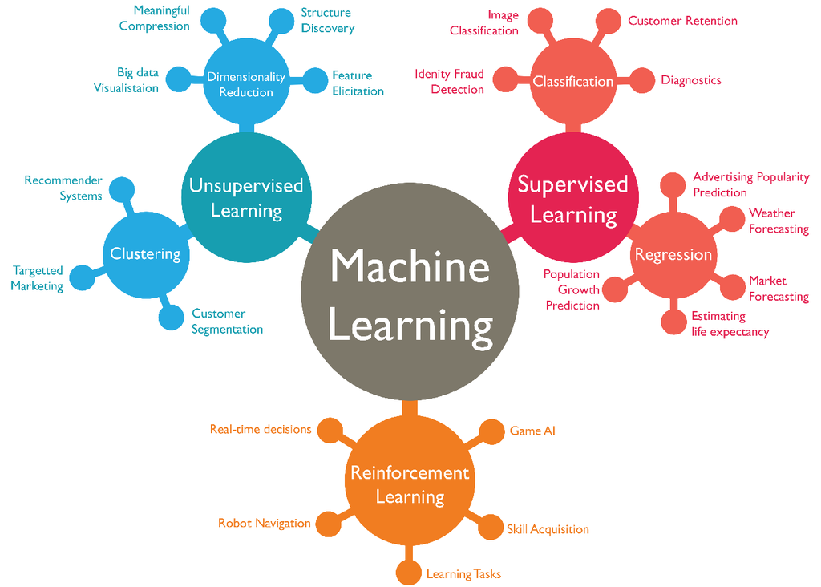

## > Компоненты классической ML задачи

- Выборка
- Ответ(target)
- Функция потерь и функционал качества
- Метрики качества
- Алгоритм\семейство моделей
- Оценка модели

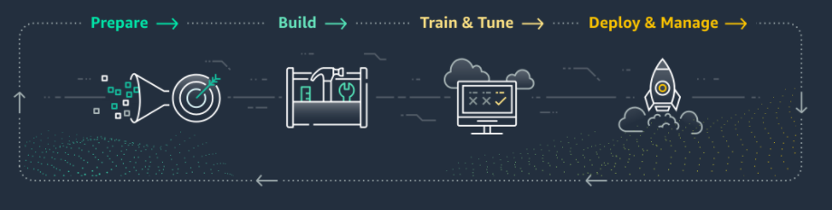

https://medium.com/maria-machine/algorithmia-introduction-to-machine-learning-d955c74ba1e4

## > Выборка: объекты и признаки (objects and features)

Выборка — набор объектов и признаков, для которых мы хотим ответить на поставленный вопрос.

**Объекты и признаки** будем обозначать латинскими буквами:

x и $d_1,d_2...d_k$ соответственно.

Таким образом, объект **x** представляет собой совокупность признаков (d):

$$x_i=(d_1 ,d_2,...,d_k)$$

Например, объект-пользователь. Его признаки — пол, возраст, интересы и т.п.

**Выборка (X)** - будет обозначать множество всех объектов с ответами (y), если они есть:

$$X={(x_i,y_i)}$$

То есть все пользователи, для которых у нас есть данные.

Признаки или фичи (features) — некоторые характеристики, на основе которых проводится обучение модели.

> Признаки бывают:

**Вещественные** — значением признака является любое число на непрерывной числовой прямой (температура тела, рост, котировки акций)

$d_j ∈ R$

**Бинарные** — когда признак может принимать одно из двух значений (М/Ж, болен/здоров, да/нет)

$d_j ∈ {0,1}$

**Категориальные** — признаки из ограниченного множества, которые невозможно упорядочить (профессиональная деятельность, город)

$d_j ∈ D$

**Порядковые** — признак принимает целое значение в некой ограниченной области (рейтинг компании)

$d_j ∈ D ⊂ Z$

**Множественные** — признак может принимать сразу несколько значений, представлен набором чисел или слов (конкуренты компании)

$d_j ∈ 2D$

## > Ответ (Target)

**Ответ (таргет) или целевая переменная** — признак датасета, который предстоит предсказывать модели машинного обучения.

Множество всех ответов будем обозначать `Y`, а ответы к каждому конкретному объекту — $y_i$.

$$Y={y}$$

Как и признаки, ответ, полученный с помощью машинного обучения, может быть:

**Вещественным** (цена акции через год)

$y_i ∈ R$

**Бинарным** (цена акций вырастет/не вырастет через год)

$y_i ∈ {0,1}$

**Множественным** (какая стратегия будет лучшей: a,b или с).

$y_i ∈ {0,1,2,3,...,d}$

**Задачи без явного таргета** (какие акции добавить в портфель: {Apple, Microsoft, Google}).

$y_i ∈ ∅$

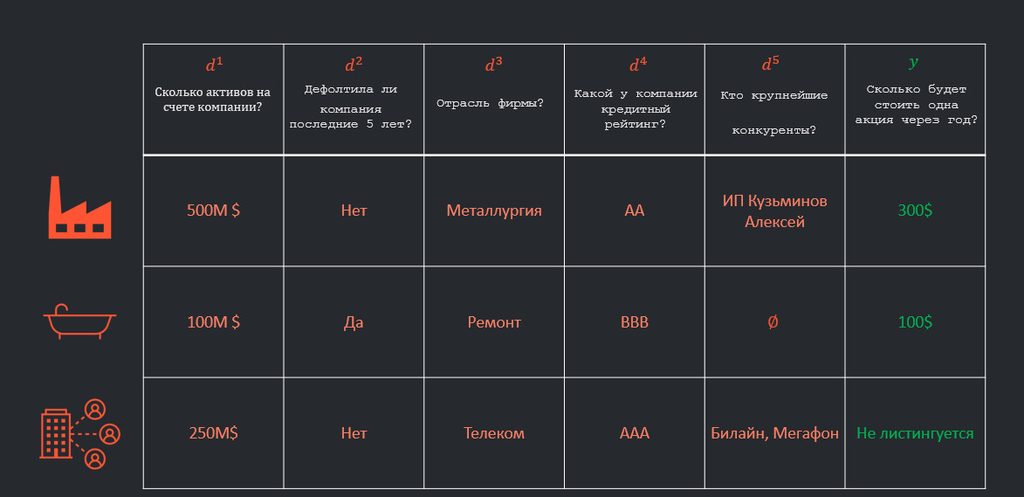